# The Diagramming Dictionary_A Complete Reference Tool for Young Writers, Aspiring Rhetoricians, and Anyone Else Who Needs to Understand How English Works.Otto2019

[figure not shown]

图表词典

THE DIAGRAMMING DICTIONARY

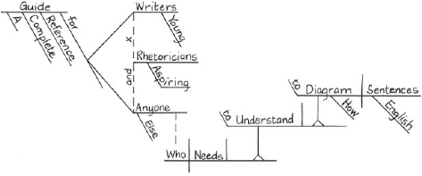

**作者****：**杰西卡 **·**奥托 和苏珊**·**怀**斯**·**鲍尔**

**B**Y **J**ESSICA **O**TTO AND **S**USAN **W**ISE **B**AUER

**D**IAGRAMS BY **P**ATTY **R**EBNE

*《图解词典》使用了苏珊·怀斯·鲍尔所著**《训练有素的思维语法*》系列中的例句：

*The Diagramming Dictionary* uses example sentences from the *Grammar for The Well-Trained Mind* series by Susan Wise Bauer:

**关于*训练有素的头脑的语法***

**ABOUT *GRAMMAR FOR THE WELL-TRAINED MIND***

*核心教师用书*

*Core Instructor Text*

脚本化的课程使任何家长或教师都能有效地使用该程序。

Scripted lessons make it possible for any parent or teacher to use the program effectively.

循序渐进的教学方法引导学生从最基础的概念逐步深入到更高级的语法概念。这本教师用书适用于*GFTWTM*系列课程的全部四年教学内容。

Step-by-step instruction takes students from the most basic concepts through advanced grammatical concepts. This instructor text is used for all four years of the *GFTWTM* series.

**学生练习册**

**Student Workbooks**

每本练习册都让学生有机会练习所学的语法。图解练习巩固语法规则，帮助技术型和视觉型学习者有效地理解和运用英语。图解过程的每个步骤都配有插图，并向学生进行详尽的解释。示例和练习选自文学名著以及科学、数学和社会科学领域的优秀非虚构类文本。每年的学习计划中都包含定期复习环节。

Each workbook allows students to practice the grammar they have learned. Diagramming exercises reinforce the rules and help technical and visual learners to understand and use the English language effectively. Each step of the diagramming process is illustrated and thoroughly explained to the student. Examples and exercises are drawn from great works of literature, as well as from well-written nonfiction texts in science, mathematics, and the social sciences. Regular review is built into each year of work.

*紫色练习册*（2017）

*Purple Workbook* (2017)

*红色练习册*（2018）

*Red Workbook* (2018)

*蓝色练习册*（2019）

*Blue Workbook* (2019)

*黄色练习册*（2021）

*Yellow Workbook* (2021)

**学生练习册答案**

**Keys to Student Workbooks**

每本练习册的答案不仅提供答案，还为家长/老师提供解释。

Each Key to the workbooks provides not only answers, but also explanations for the parent/teacher.

*紫色练习册答案*（2017）

*Key to Purple Workbook* (2017)

*红色练习册答案*（2018）

*Key to Red Workbook* (2018)

*蓝色练习册答案*（2019）

*Key to Blue Workbook* (2019)

*黄色练习册答案*（2021）

*Key to Yellow Workbook* (2021)

*语法指南*

*The Grammar Guidebook*

*《语法指南》*既可*作为“优秀思维*语法”课程的配套教材，也可作为终身参考书独立使用。本书汇集了英语语言的所有基本原则，从基本定义（“名词是人、地点、事物或概念的名称”）到高级句型结构和分析，应有尽有。每条规则都配有选自文学名著以及经典和当代科学、历史和数学著作的例句。

Capable of accompanying the *Grammar for the Well-Trained Mind* program or standing on its own as a lifelong reference companion, *The Grammar Guidebook* assembles into one handy reference work all of the principles that govern the English language—from basic definitions (“A noun is the name of a person, place, thing, or idea”) through advanced sentence structure and analysis. Each rule is illustrated with examples drawn from great literature, along with classic and contemporary works of science, history, and mathematics.

目录

TABLE OF CONTENTS

IA. 简单主题

IA. Simple subjects

IB. 简单谓语

IB. Simple predicates

IIA. 形容词

IIA. Adjectives

IIB. 副词

IIB. Adverbs

IIIA. 介词短语作修饰语

IIIA. Prepositional phrases acting as modifiers

IIIB. 作名词的介词短语

IIIB. Prepositional phrases acting as nouns

IIIC. 介词宾语，特殊情况

IIIC. Objects of prepositions, special cases

IVA。直接宾语

IVA. Direct objects

间接宾语

IVB. Indirect objects

VA. 表语形容词

VA. Predicate adjectives

VB. 表语名词

VB. Predicate nominatives

VIA. Phrases

VIB. 独立分句

VIB. Independent clauses

VIIC. 从属子句

VIIC. Dependent clauses

前言

FOREWORD

一旦你学会了如何分析句子结构，你就会*真正*理解英语的运作方式。

Once you learn how to diagram sentences, you’ll *really* understand how English works.

要分析句子结构，你需要掌握的不仅仅是词类的定义，还需要了解这些词类是如何协同作用来表达意义的。这能让你成为更优秀的写作者。

To diagram a sentence, you have to know more than just memorized definitions of parts of speech. You have to know how those parts of speech work together to produce meaning. And that makes you a better writer.

不妨这样想：任何人都可以走进一栋建筑，指出浴室、走廊、楼梯或厨房的位置。但这并不能解释建筑是如何运作的，以及为什么会这样运作。只有蓝图才能揭示真正的底层结构——正是这种结构使建筑能够正常运转。

Think of it this way: Anyone can walk into a building and point out the bathroom, hallway, stairs, or kitchen. But that doesn’t explain how and why the building functions. Only a blueprint will reveal the true underlying structure—the structure that makes the building functional.

你可以不看蓝图就漫步在建筑物里，也可以不画句子结构图就专心阅读。但要设计一座实用的建筑，或者写出一个有效的句子，你需要更深入的知识。你需要知道各个部分是如何组合在一起的。

You can wander through a building without ever looking at the blueprint, and you can be a contented reader without ever sketching out a sentence diagram. But to design a useful building, or to put together an effective sentence, you need a deeper knowledge. You need to know how the parts all fit together.

句子结构图不仅能加深你对英语的理解，还能为你提供一个诊断工具，帮助你判断自己的句子是强还是弱，以及原因。

Diagramming doesn’t just deepen your understanding of the English language; it also gives you a diagnostic tool to figure out whether your own sentences are weak or strong, and why.

请看下面这句优美而平衡的句子，它出自十九世纪诗人杰拉德·曼利·霍普金斯之手：

Consider the following balanced and beautiful sentence, from nineteenth-century poet Gerard Manley Hopkins:

*我们的祈祷和上帝的恩典就像井里的两个水桶；一个上升时，另一个下降。*

*Our prayer and God’s grace are like two buckets in a well; while the one ascends, the other descends.*

请大声朗读这句话，然后再大声朗读下面这个学生写的句子。听听有什么不同。

Read it out loud, and then read the following student sentence out loud. Listen to the difference.

*在*《傲慢与偏见》中*，伊丽莎白的母亲举止粗鲁，一心想结婚，这让她感到不满。*

*In* Pride and Prejudice*, her mother’s bad manners and wishing to get married made Elizabeth discontent.*

第二句话意思没错，但写得不好。它显得苍白无力，笨拙生硬。为什么呢？

The second sentence makes sense—but it isn’t a pretty sentence. It’s weak and clunky. Why?

是时候画图了！

Time to diagram!

在霍普金斯句子中，第一个独立分句的主语和谓语可以用以下图示表示：

In the Hopkins sentence, the subject and verb of the first independent clause are diagrammed like this:

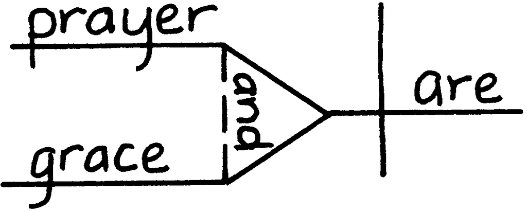

第二句也采用了复合主语和单个谓语的结构：

The second sentence also has a compound subject and single verb:

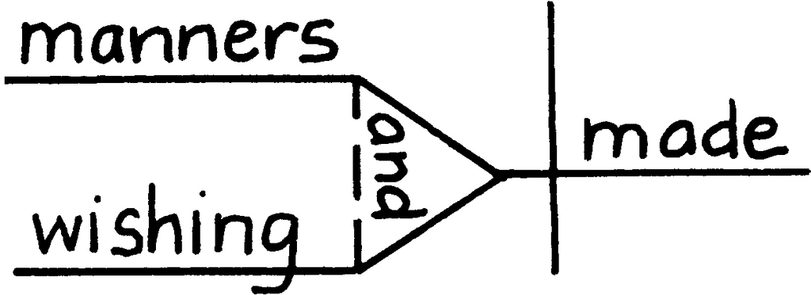

但在第二句中，这两个主语是两种不同的词性。“Manners”是名词，而“wishing”是动名词——动词用作名词的形式。在结构式中，位置相同的词应该采用相同的形式——就像霍普金斯句子中的“prayer”和“grace”都是名词一样。

But in the second sentence, the two subjects are two different kinds of words. “Manners” is a noun, while “wishing” is a gerund—a verb form used as a noun. Words which occupy parallel places on a diagram should take the same form—as in the Hopkins sentence, where “prayer” and “grace” are both nouns.

现在你知道为什么第一句话听起来酣畅淋漓，而第二句话却显得沉重乏味了吧。

Now you know why the first sentence soars, and the second one thuds.

这里还有一个例子。不画图，你能弄明白为什么下面的句子行不通吗？

Here’s another example. Without diagramming, can you figure out why the following sentence doesn’t work?

*除了城市之外，西奥多·德莱塞笔下的社会也通过人物来展现。*

*In addition to the city, Theodore Dreiser’s society is depicted in its people.*

这是一个很别扭、很难懂的句子。用句型分析就能看出原因。

It’s an awkward, ugly sentence. Diagramming it shows why.

这里用简单的主谓线图表示主语（社会）和谓语（被描绘），介词短语“在其人民中”用图解表示在谓语下方（它充当副词，因为它回答了“如何”的问题）。

Here are the subject (society) and verb (is depicted), diagrammed on a simple subject/verb line, with the prepositional phrase “in its people” diagrammed underneath the verb (it is acting as an adverb, because it answers the question “how”).

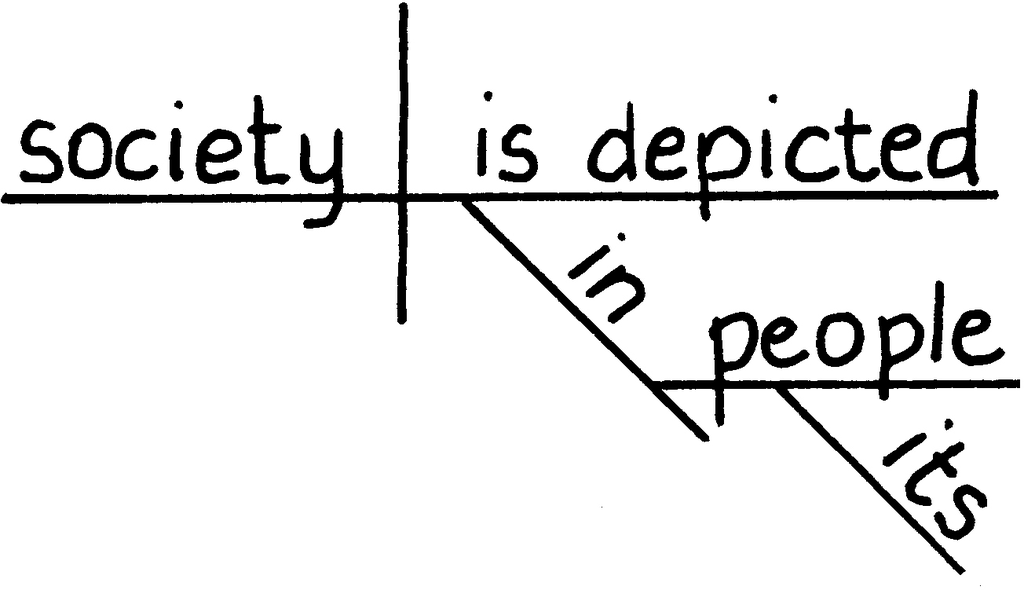

但是“除了城市之外”应该放在哪里呢？

But where should “In addition to the city” go?

它似乎不属于任何范畴。画面中是否同时描绘了社会和城市？（如果是，二者有何区别？）社会是通过其成员还是通过其城市来展现的？（两者都不太明确。）

It doesn’t seem to fit anywhere. Are the society and city both depicted? (If so, what’s the difference?) Is the society depicted in its people or in its city? (Neither is particularly clear.)

如果不能把它放到图表上，它就不应该出现在句子中。这句话的作者并不完全理解德莱塞描绘的是什么，他希望用自己模糊的理解蒙混过关。

If you can’t put it on the diagram, it doesn’t belong in the sentence. The author of this sentence doesn’t exactly know what Dreiser is depicting, and he’s hoping to sneak his fuzzy comprehension past the reader.

请记住一点：本词典中的示例图样整齐美观，但你的图表不必如此。成功的图表绘制需要大量的擦除、重写，甚至超出纸张边缘。好的图表通常会有涂改痕迹和修改。你的图表不必像建筑图纸那样严谨，它们可以是随意的铅笔草图，也可以是艺术作品。

Here’s something important to keep in mind: The examples in this Dictionary are neat and tidy, but your diagrams don’t need to be. Successful diagramming takes a lot of erasing and rewriting and running off the edge of the paper. Good diagrams often have scribbled-out parts and corrections. Your diagrams don’t have to look like architectural plans. They can look like messy pencil sketches or works of art.

以下是一些建议：

Here are a few suggestions:

不要用钢笔画图！你最初画的句子结构图可能需要随着写作的进行而修改。使用一支软铅笔，笔尖要削尖，并且务必准备一块橡皮擦。因为你*需要*边画边擦，反复修改。

Don’t diagram in pen! Your first approach to the sentence will probably need fixing as you progress on. Use a soft lead pencil, nice and sharp, and be sure to keep a separate eraser on hand. Because you *will* need to erase and redraw as you go.

不要在有规则横格线的纸上画图——要么用白纸，要么用方格纸（方格纸适合那些喜欢线条整齐的绘图者）。如果用方格纸，蓝色线条比黑色线条好，因为这样可以清楚地分辨哪些是铅笔画的，哪些是网格线。

Don’t diagram on paper with regular ruled lines—use either plain sheets of paper, or else graph paper (that’s for diagrammers who really like all of their lines to be tidy). If you do use graph paper, blue lines are better than black, because you can see what is pencil and what is grid line.

如果你的图表超出了纸张边缘，只需用胶带把另一张纸粘到第一张纸上就行了。你不需要重做整张图！

If your diagram runs off the edge of the page, just tape another piece of paper to the first one. You don’t have to redo the whole thing!

线条不必完全笔直！如果你*真的*想的话，可以使用尺子或三角尺，但只要图表的各个部分在正确的位置相互连接，就不用担心线条的弯曲程度。

Lines don’t have to be perfectly straight! You can use a ruler or triangle if you *really* want to, but as long as the different parts of the diagram connect to each other in the right places, don’t worry about how much the lines twist and turn.

以下是苏珊对以下句子（出自*本杰明·富兰克林自传*）的原始草稿：

Here’s Susan’s original sketch of the following sentence (from *The Autobiography of Benjamin Franklin*):

*就这样，我们整夜躺着，几乎没有休息；但第二天风势减弱，我们赶在天黑前到达安博伊，在水上漂了三十个小时，没有食物，也没有饮料，只有一瓶劣质朗姆酒，因为我们航行的水是咸的。*

*In this manner we lay all night, with very little rest; but the wind abating the next day, we made a shift to reach Amboy before night, having been thirty hours on the water, without victuals, or any drink but a bottle of filthy rum, the water we sailed on being salt.*

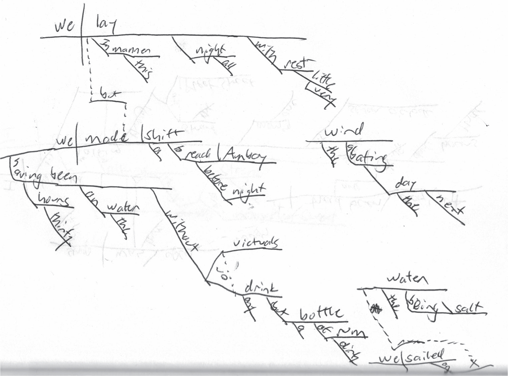

这些线条肯定不是直线。但看看这句话的图形设计版本，多么简洁美观啊！

Those are definitely not straight lines. But now look how neat and tidy the graphic design version of this sentence is.

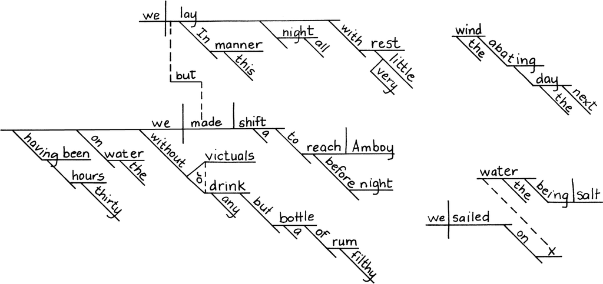

两个图都正确！画图时，更应该关注所展示的功能和关系，而不是图的形状或整洁程度。只要线条连接的是正确的词语，图就没问题。

Both diagrams are correct! When you’re diagramming, pay more attention to the functions and relationships shown, not the shape or tidiness of the diagram. As long as the lines are connecting the right words, the diagram is fine.

这些句子可以用不同的方式将恰当的词语连接起来。以下是欧·亨利短篇小说《警察与颂歌》中的一句话：

And those lines can connect the right words in different ways. Here’s a sentence from the O. Henry short story “The Cop and the Anthem”:

*透过一扇紫罗兰色的窗户，柔和的光线透了出来，毫无疑问，管风琴师正徘徊在琴键前，确保自己能熟练地演奏即将到来的安息日圣歌。*

*Through one violet-stained window a soft light glowed, where, no doubt, the organist loitered over the keys, making sure of his mastery of the coming Sabbath anthem.*

画图时，重要的是用虚线连接“光”和“哪里”（“哪里”是关系副词，连接描述性从句和主句的主语）。但这条线可以朝任何方向延伸。以下是一种画法：

When you diagram this, it’s important that a dotted line connect “light” to “where” (“where” is a relative adverb linking the descriptive clause to the subject of the main clause). But that line can go in any direction. Here’s one way to do it:

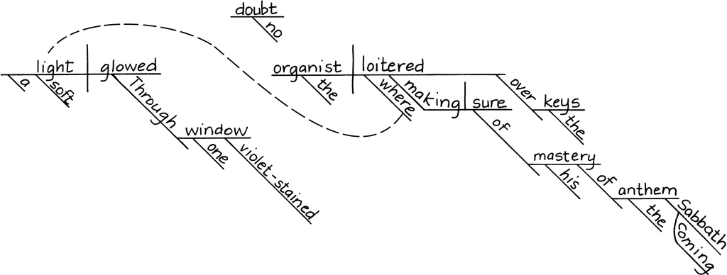

但是，左撇子学生可能更喜欢画成上下方向的图，而不是横向的图，这样就不会在独立分句上留下污迹。

But a left-handed student would probably prefer to make the diagram up-and-down, rather than wide, so that she doesn’t leave smudges on the independent clause.

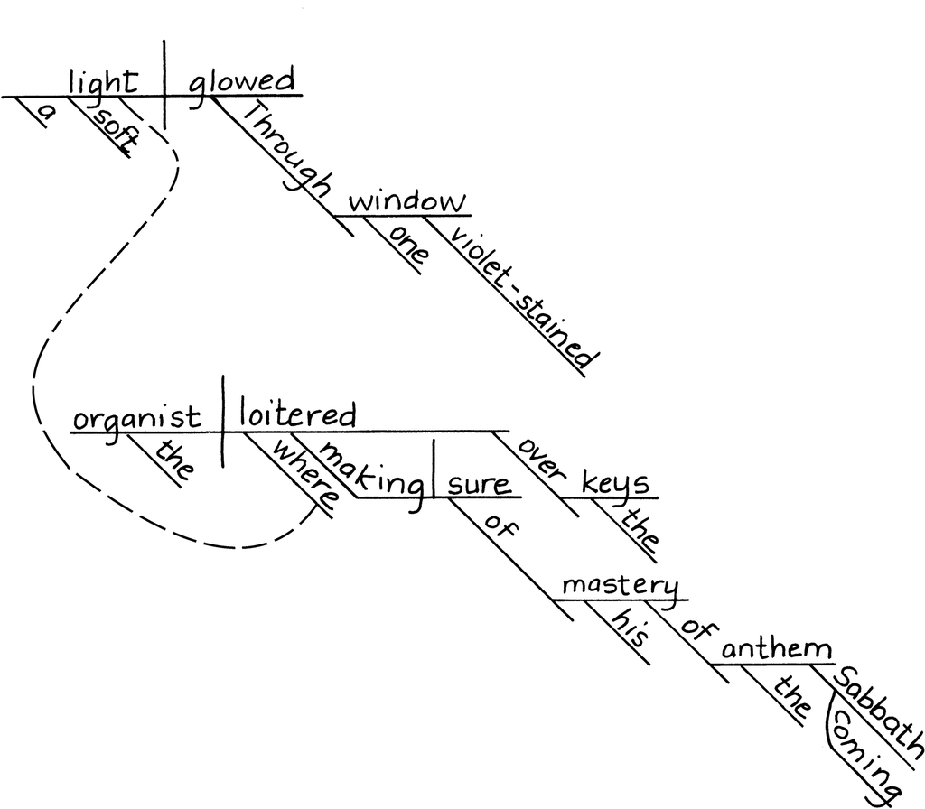

有时候，图表中的一些小元素也很重要。例如，介词用一条斜线表示，介词的宾语则用一条水平线表示，这条水平线在斜线末端附近分叉，使斜线略微拖长。但不定式则用一条弯曲的直线表示，没有拖尾。这一点很重要，因为所有不定式都以“to”开头，但“to”也可以作介词。图表展示了“to”作词的性质。

Sometimes, small elements of diagrams are important. For example, prepositions are diagrammed on a slanting line, with their objects on a horizontal line that branches off the slant just before it ends, so that the slanting line has a little tail. But infinitives are diagrammed on a bending line with no tail. This is important because all infinitives begin with “to,” but “to” can also be a preposition. The diagram shows you what kind of word “to” is.

介词

preposition

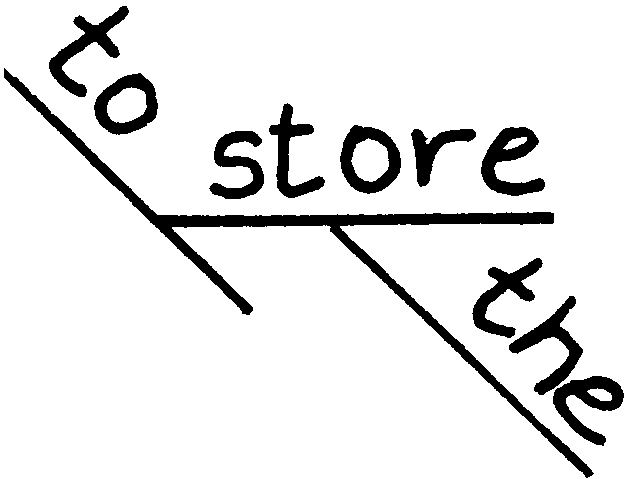

不定式的一部分

part of an infinitive

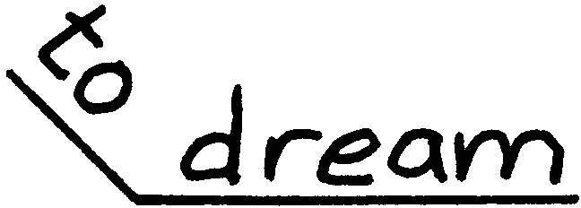

但是，你用来表示现在分词的线条是向右弯曲还是呈锐角，这重要吗？绝对不重要，因为很明显，这个词是现在分词。

But does it matter whether the line you diagram your present participle on curves to the right or has a sharp angle? Absolutely not, because it’s perfectly clear that the word is a present participle.

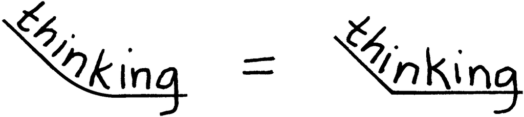

所以，不要执着于把图表做得“完美”。尽力用对你有帮助的方式展现词语之间的关系。记住：图表并非一项晦涩难懂、旨在折磨年轻写作者的作业。相反，它能促使他们理清思路、修改句子，并将语法运用到写作中——毕竟，这才是语法存在的意义。

So don’t get overwhelmed by making your diagrams somehow “perfect.” Do your best to represent the relationship between the words in a way that’s helpful to you. And remember: Diagramming isn’t an arcane assignment designed to torture young writers. Instead, it forces them to clarify their thinking, fix their sentences, and put grammar to use in the service of writing—which is, after all, what grammar is for.

开始之前

BEFORE WE BEGIN

在开始之前，让我们回顾一下图表绘制中最基本的技能：如何绘制主语和谓语的图表！

Before we begin, let’s review the most basic skill in diagramming: how to diagram a subject and predicate!

首先，画一条水平线。然后，用一条垂直线将这条线平分。确保垂直线完全穿过水平线。这条垂直线将主语部分与谓语部分完全分开。

First, draw a horizontal line. Next, divide the line in half with a vertical line. Make sure your vertical line goes all the way through the horizontal line. This vertical line divides everything in the subject from everything in the predicate.

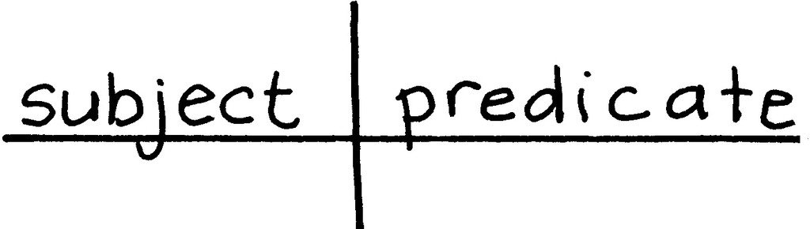

简单主语位于竖线左侧，简单谓语位于竖线右侧。完整主语的所有成分都与图表左侧相连，完整谓语的所有成分都与图表右侧相连。绘制图表时请牢记这一点！在接下来的示例中，每个简单主语都用一条下划线标出，每个简单谓语都用两条下划线标出。有些句子包含多个主语和谓语，尤其是在由多个从句组成的句子中。

The simple subject goes to the left of the vertical line. The simple predicate goes to the right of the vertical line. Everything in the complete subject will attach itself to the diagram on the left. Everything in the complete predicate will attach itself to the right. Keep that in mind for everything you diagram! In the examples that follow, every simple subject is underlined once, and every simple predicate is underlined twice. Some sentences contain more than one subject and predicate, especially if they are made up of multiple clauses.

在每个例句中，你会看到一些单词是绿色的。这表示我们在该示例中重点关注的句子部分。

In each sample sentence, you will see that some of the words are in green. That indicates the part of the sentence we are focusing on in that particular example.

注意：绘制图表时，务必保留原文的首字母大写！（因此，请确保图表中句子的第一个单词首字母大写。）图表中不需要标点符号（尽管有时可以用*x*表示标点符号）。

Note: When you are diagramming, always keep the capitalization of the original! (So be sure to capitalize the first word of the sentence on your diagram.) Punctuation does not go on diagrams (although sometimes you may represent punctuation with an *x*).

第一部分：如何绘制句子的简单主语和简单谓语图

PART I: HOW TO DIAGRAM THE SIMPLE SUBJECT AND SIMPLE PREDICATE OF A SENTENCE

IA. 简单主题

IA. Simple subjects

**1. 普通名词**作主语：当普通名词用作句子的主语时，将其放在主题行。

**1. Common nouns** as subjects: When a common noun is used as the subject of a sentence, put it on the subject line.

书是打开的。

The book is open.

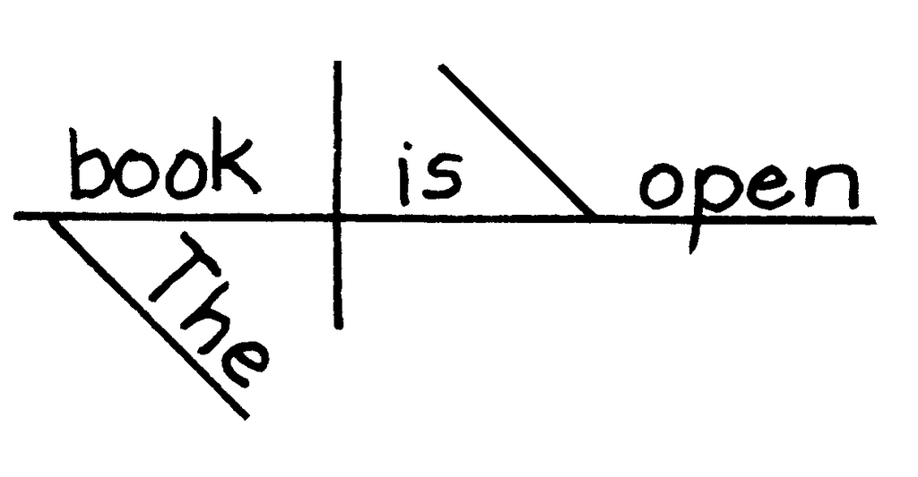

**2. 主语**为“你”：在祈使句中，主语默认为“你”。在图表的主题行中，它被放在括号中，以表明它本身并不出现在句子中。

**2. The understood you** as subject: In a command (imperative) sentence, the subject is understood to be “you.” It is placed in parentheses on the subject line of the diagram to show that it does not appear in the sentence itself.

合上书。

Close the book.

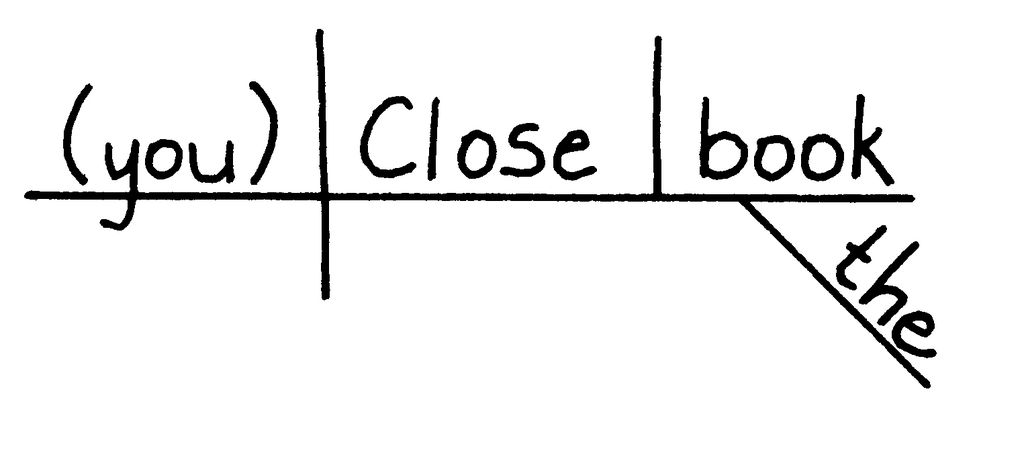

**3. 代词**作主语：人称代词通常是句子的主语，其结构图与它所代替的名词的结构图完全相同。

**3. Pronouns** as subjects: A personal pronoun is often the subject of a sentence and is diagrammed exactly as the noun it is replacing would be diagrammed.

你今天 做得很好。

You did a good job today.

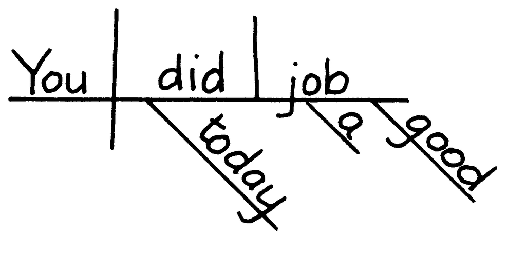

**4. 复合名词**作主语：复合名词可以是两个独立的词，也可以是用连字符连接的两个词，或者合并成一个词的两个词。复合名词在图表中始终保持在同一位置。

**4. Compound nouns** as subjects: A compound noun can be two separate words, two words joined by a hyphen, or two words that have been combined into one. A compound noun is always kept together on the same space of the diagram.

不幸的误会时 有发生。

Unfortunate mix-ups happen.

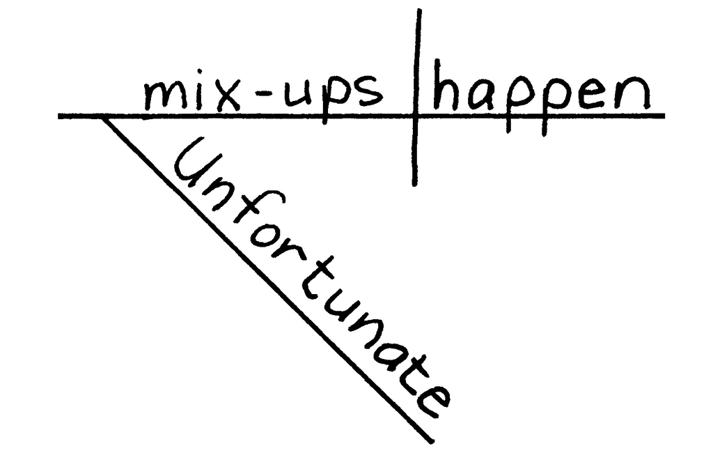

你的台灯 亮了。

Your desk lamp illuminates.

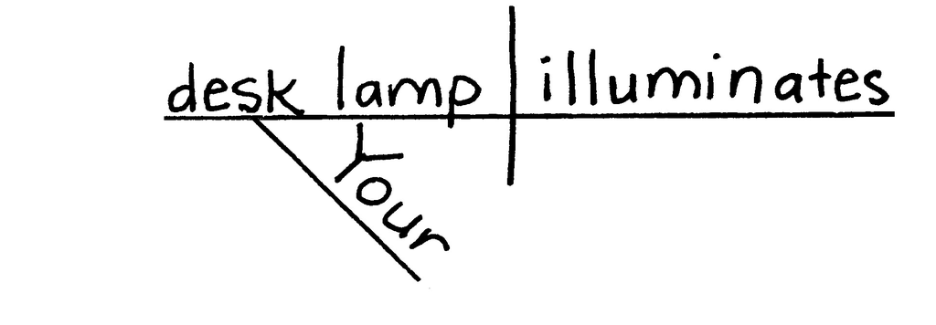

**5. 并列主语**：并列主语由两个或多个主语通过连词连接而成。并列主语的图示方法是将主语线分成两个括号，每个主语分别放在括号内的一条水平线上。然后，用一条垂直虚线连接这些水平线，并将连词放在这条虚线上。

**5. Compound subjects**: A compound subject consists of two or more subjects joined by a conjunction. A compound subject is diagrammed by splitting the subject line into a bracket and placing each individual subject on its own horizontal line of the bracket. Then, a vertical dotted line joins the horizontal lines, and the conjunction is placed on that dotted line.

马科斯和 卡罗琳娜 正在和他们的妈妈一起做饼干。

Marcos and Carolina are making cookies with their mother.

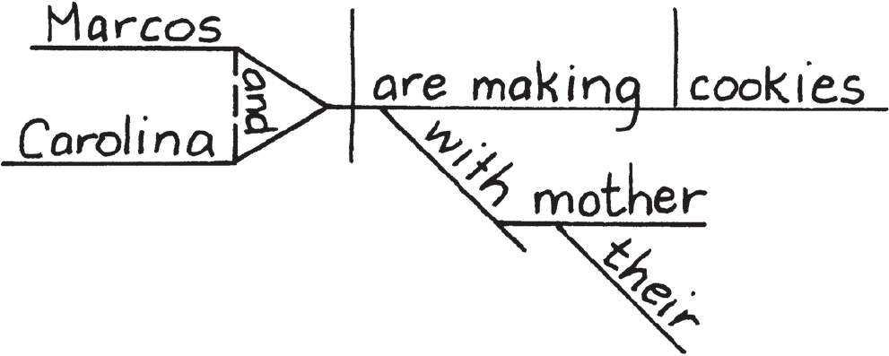

您可以使用*x*来表示逗号已代替并列连词，但这并非必须。

You may use an *x* to show that a comma has replaced a coordinating conjunction, but this is optional.

她 想都没想，就离开了小路，一头扎进田野，摔倒在草地上<sup>。</sup>

There, without a thought, she left the pathway, plunged into a field, and fell on the grass.*

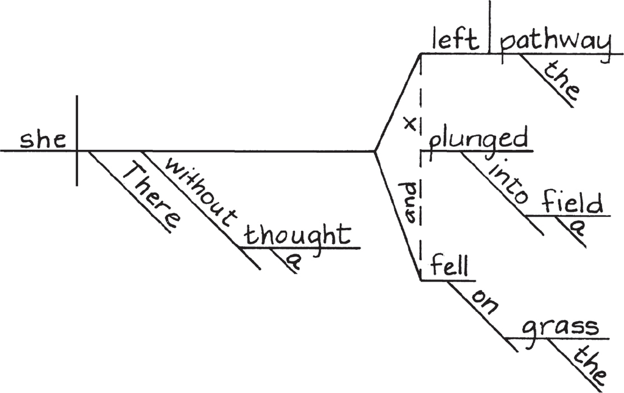

**6. 并列主语与多个并列连词**：当一个句子包含两个以上的主语，且由多个并列连词连接时，将两个并列连词都放在虚线上的括号内。

**6. Compound subjects with more than one coordinating conjunction**: When a sentence contains more than two subjects joined by more than one coordinating conjunction, place both conjunctions inside the bracket on the dotted line.

马 、猎犬和号角都属于正在播种玉米的 农夫。

The horse and the hound and the horn belonged to the farmer sowing his corn.

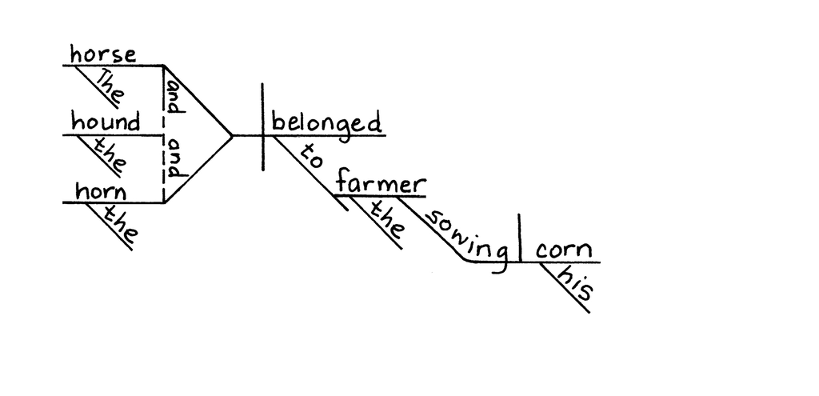

**7. 专有名词**作主语：当一个包含多个单词的专有名词作主语时，无论是人名、书名，还是船名或飞机名，专有名词的单词都不会分开，而是放在图表的主题行上。

**7. Proper nouns** as subjects: When a proper noun with more than one word is a subject, whether it is a person’s name, the title of a book, or the name of a ship or airplane, the words of the proper noun are not split up but are placed together on the subject line of the diagram.

斯帕罗夫人和 她的家人在一起。 †

Lady Sparrow was with her family.†

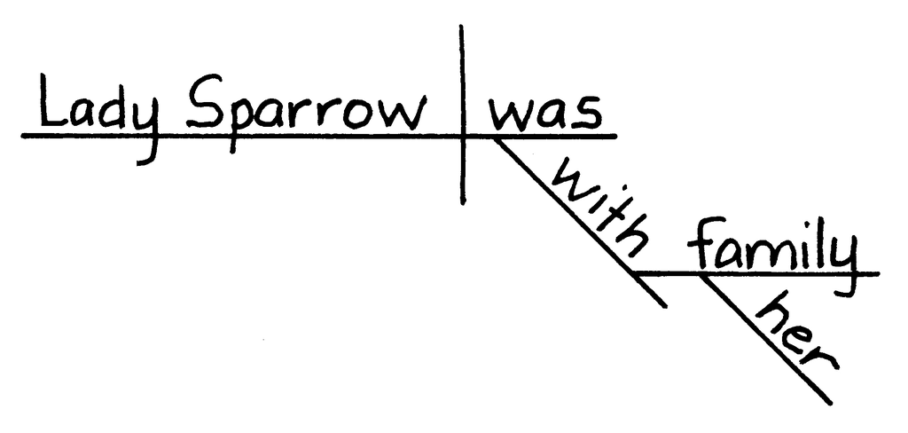

北极星*号* 驶入了冰层中的一个小海湾。

The *North Star* made her way into a small inlet in the ice.

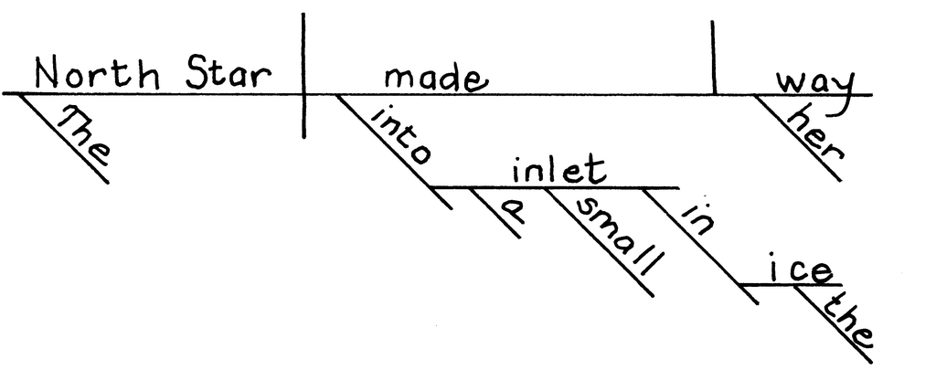

**8. 不定代词**作主语：不定代词（没有先行词的代词）可以作主语，放在图表的主语线上。

**8. Indefinite pronouns** as subjects: An indefinite pronoun (a pronoun without an antecedent) can be a subject and is placed on the subject line of the diagram.

有人 拖着一条链子<sup>。</sup>

Someone was dragging a chain.‡

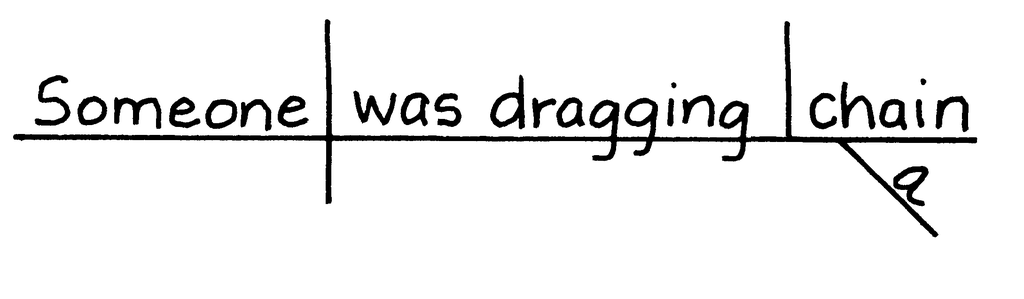

**9. 介词短语**作主语：主语不能出现在介词短语内部，但整个介词短语可以作主语。它在句子的主语行上用方框标出，短语的任何修饰语都附在它上面。

**9. Prepositional phrases** as subjects: A subject can never be found inside of a prepositional phrase, but an entire prepositional phrase can serve as a subject. It is diagrammed on a pedestal on the subject line of the sentence, with any modifiers of the phrase attached to it.

桥下 不是安全的地方。

Under the bridge is not a safe place.

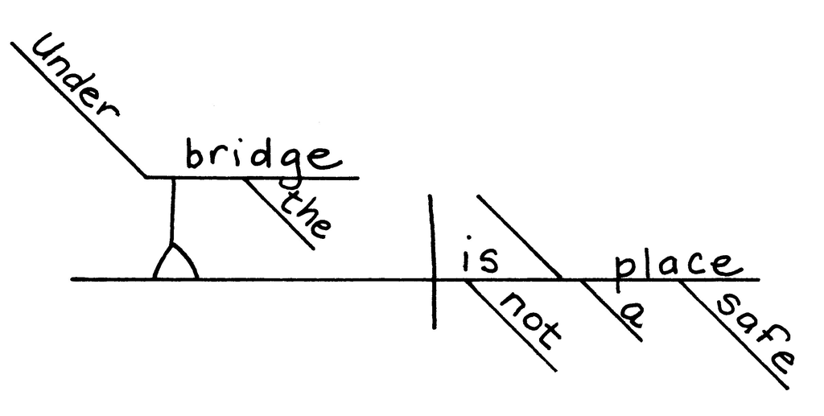

**10. 指示代词**作主语：指示代词可以作句子的主语，如果作主语，则放在主题行。

**10. Demonstrative pronouns** as subjects: A demonstrative pronoun can act as the subject of a sentence, and if it is acting as the subject, it is placed on the subject line.

这 味道真好。

This tastes delectable.

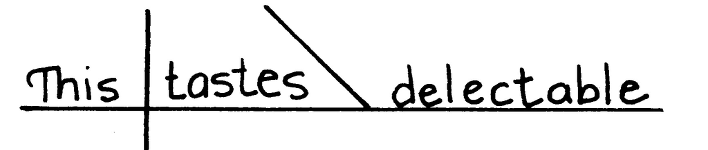

**11. 疑问代词**作主语：疑问代词可以作句子的主语，如果作主语，则放在主题行。

**11. Interrogative pronouns** as subjects: An interrogative pronoun can act as the subject of a sentence, and if it is acting as the subject, it is placed on the subject line.

谁 赋予你评判你兄弟的权力？

Who made you the judge of your brother?

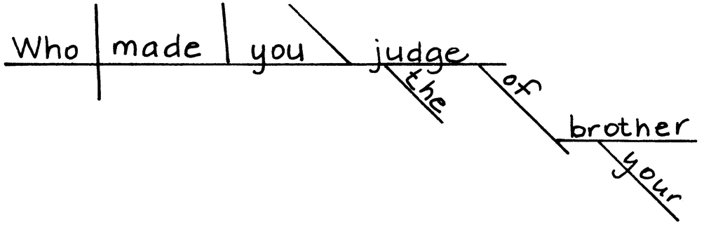

**12. 缩写**作为主语：当主语是缩写的一部分时，只将缩写的代词部分放在主题行上。

**12. Contractions** as subjects: When a subject is part of a contraction, put only the pronoun part of the contraction on the subject line.

我差点摔断脖子<sup>。</sup>

I’ve almost broken my neck.<sup>§</sup>

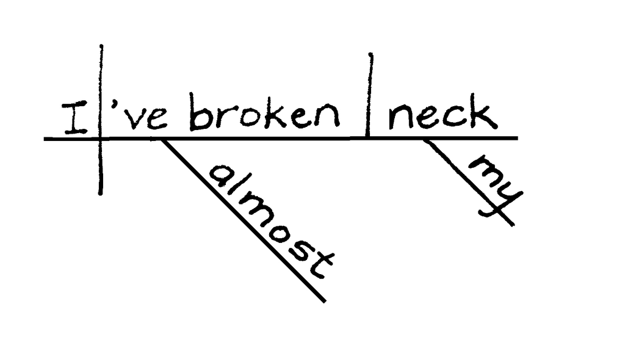

**13. 带有主语的强调代词**：当一个强调代词用来加强主语的语气时，将其用括号括起来，放在主语后面，以表明它是句子中非必要成分。

**13. Intensive pronouns** with a subject: When an intensive pronoun is adding intensity to a subject, diagram it in parentheses after the subject to demonstrate that it is a non-essential element in the sentence.

木星的阴影遮蔽了三颗内侧卫星。

The three inner satellites themselves are eclipsed by the shadow of Jupiter.

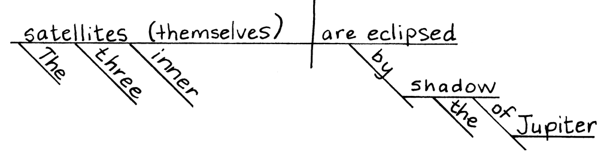

**14. 动名词**作主语：作主语的动名词在主题行中被置于基座上。它用虚线表示，以表明它既是名词又是动词。

**14. Gerunds** as subjects: A gerund acting as a subject is placed on a pedestal on the subject line. It is diagrammed on a broken line to show that it is both noun and verb.

小母马奔跑起来筋疲力尽。

Galloping exhausted the little mare.

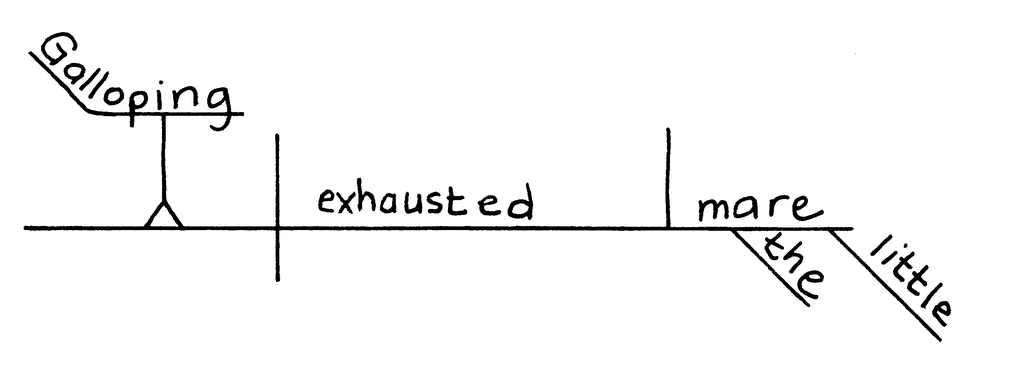

**15. 不定式**作主语：作主语的不定式放在主题行的基座上。它用虚线表示，以表明它既是名词又是动词。

**15. Infinitives** as subjects: An infinitive acting as the subject is placed on a pedestal on the subject line. It is diagrammed on a broken line to show that it is both noun and verb.

给予 即是获得。

To give is to receive.

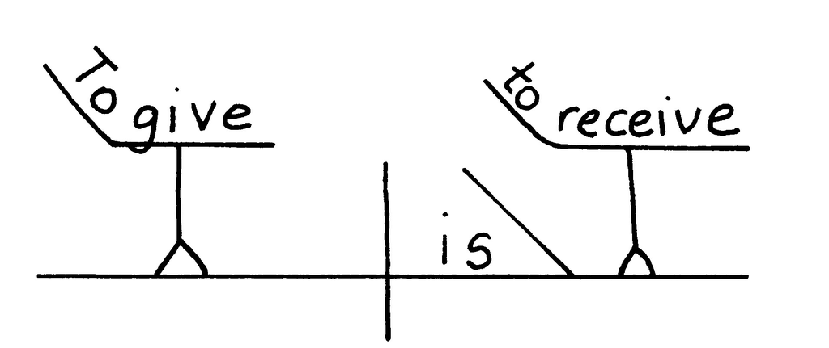

**16.****并列连词连接**复合主语：连接复合主语的连词的图示与并列连词相同，只是用省略号连接连接线上的连词。

**16.** Compound subjects with **coordinating correlative conjunctions**: A correlative conjunction joining compound subjects is diagrammed just as a coordinating conjunction, except an ellipsis is used to connect the conjunctions on the joining line.

起初，太阳和月亮都是黑暗的。

In the beginning, both the Sun and the Moon were dark.

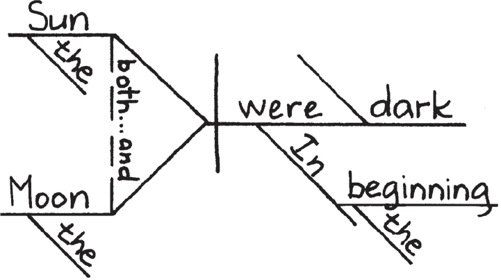

**17.**主语后的同位语名词：在绘制同位语名词的图解时，将其放在它所重新命名或解释的名词后面的括号中。

**17. Appositive nouns** after subjects: When diagramming an appositive noun, place it in parentheses after the noun it renames or explains.

罗马的第一位统治者罗穆卢斯杀死了他的兄弟并夺取了政权。

Rome’s first ruler, Romulus, killed his brother and seized power.

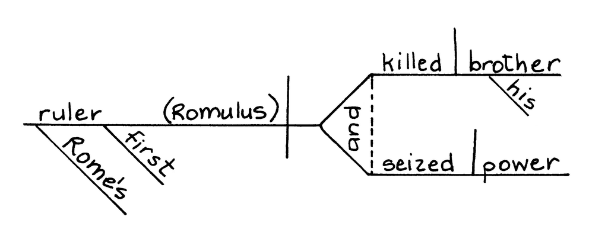

**18. 祈使动词中的未知主语**：使用*let*的祈使句通常将动作赋予未知的主语。在主语栏中用*x*标记以表示未知主语。

**18. Unknown subjects with hortative verbs**: Hortative sentences that use *let* are often assigning the action to an unknown subject. Mark the subject line with an *x* to indicate an unknown subject.

让我们安全出行。

Let us travel safely.

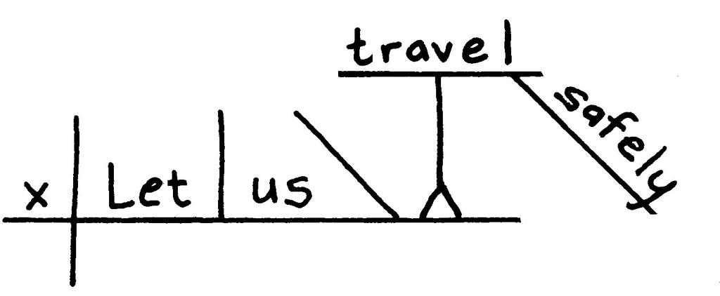

IB. 简单谓语

IB. Simple predicates

**1. 助动词：**将所有助动词放在谓语行上主要动词的旁边。可以有多个助动词。

**1. Helping verbs:** Put any helping verbs next to the main verb on the predicate line. There may be more than one helping verb.

其他动物 也聚集在<sup>周围</sup>。

Other animals were gathering around.<sup>¶</sup>

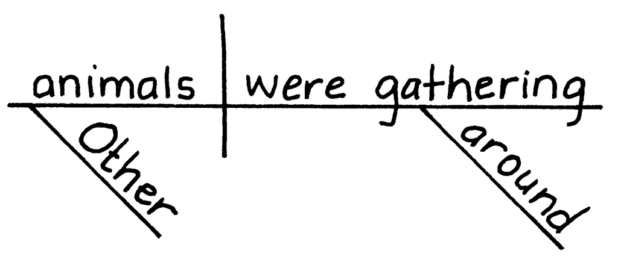

到那时，他们 就会吸取教训<sup>了</sup>。

By that time, they will have learned their lesson.<sup>#</sup>

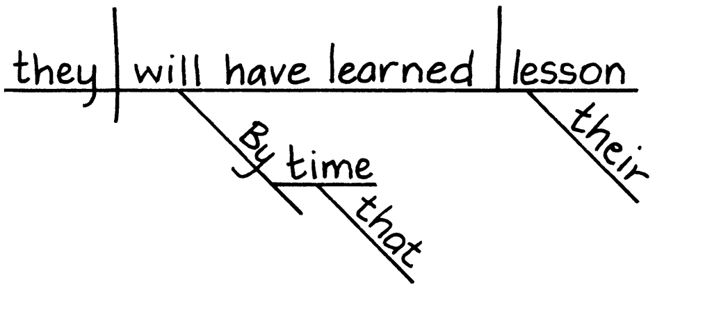

**2. 复合谓语：**复合谓语由两个或多个动词通过连词连接而成。复合谓语的图示方法是：在主谓分界线之后，将谓语线分成两部分，并用括号括起来。每个谓语都放在括号的一条水平线上。然后，用一条垂直的虚线连接这些水平线，连词就放在这条虚线上。

**2. Compound predicates:** A compound predicate consists of two or more verbs joined by a conjunction. Compound predicates are diagrammed by splitting the predicate line into a bracket after the subject/predicate dividing line. Each predicate is placed on its own horizontal line of the bracket. Then, a vertical dotted line joins the horizontal lines, and the conjunction is placed on that dotted line.

马科斯 加入 食材并 搅拌。

Marcos adds and stirs the ingredients.

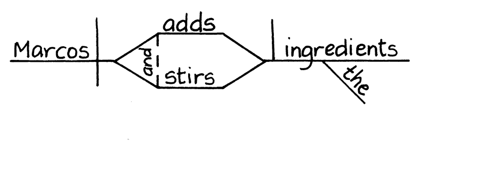

**3. 复合谓语与多个并列连词**：当一个句子包含两个以上谓语，且这些谓语由多个并列连词连接时，请将所有并列连词都放在虚线括号内。您可以使用“ *x”*来表示逗号已代替并列连词，但这并非必须。

**3. Compound predicates with more than one coordinating conjunction**: When a sentence contains more than two predicates joined by more than one coordinating conjunction, place both conjunctions inside the bracket on the dotted line. You may use an *x* to show that a comma has replaced a coordinating conjunction, but this is optional.

希德 打了个哈欠，伸了个懒腰，然后哼了一声，用手肘撑起身子，盯着 汤姆<sup>看</sup>。

Sid yawned, stretched, and then brought himself up on his elbow with a snort and stared at Tom.**

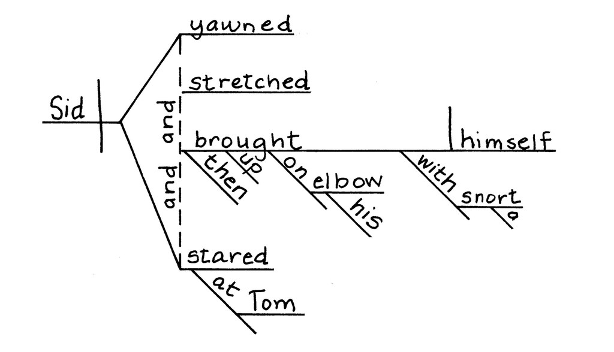

**4. 缩写作为谓语：**在绘制缩写动词的图时，只将动词的缩写部分放在谓语空间中。

**4. Contractions as predicates:** When diagramming a contracted verb, place only the contracted portion of the verb in the predicate space.

它不在那里。

It’s not there.

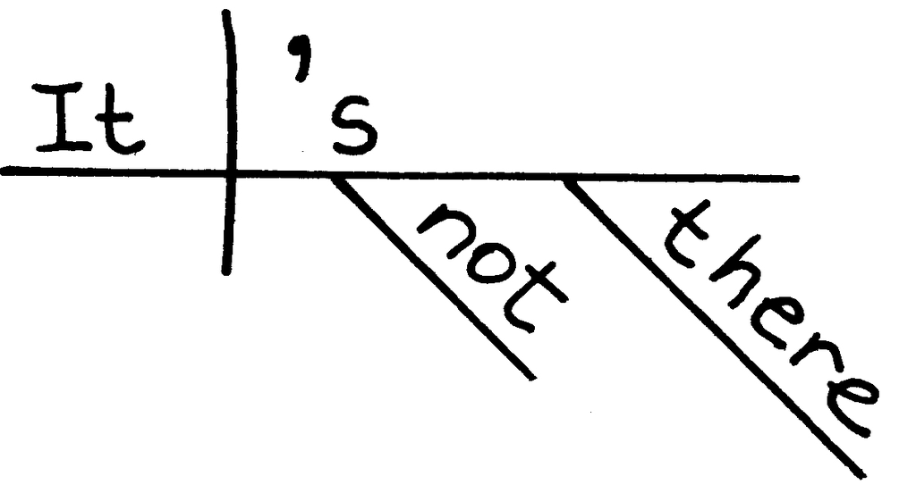

**5. 隐含的助动词：**当一个句子包含两个或多个主要动词和一个适用于所有主要动词的助动词时，用 x 表示隐含的助动词*。*

**5. The understood helping verb:** When a sentence contains two or more main verbs and one helping verb that applies to all of the main verbs, designate the understood helping verb with an *x.*

细密的雪花在<sup>灰色</sup>草原上簇拥着的低矮灰暗的建筑群周围飘舞盘旋。

A mist of fine snowflakes was curling and eddying about the cluster of low drab buildings huddled on the grey prairies.††

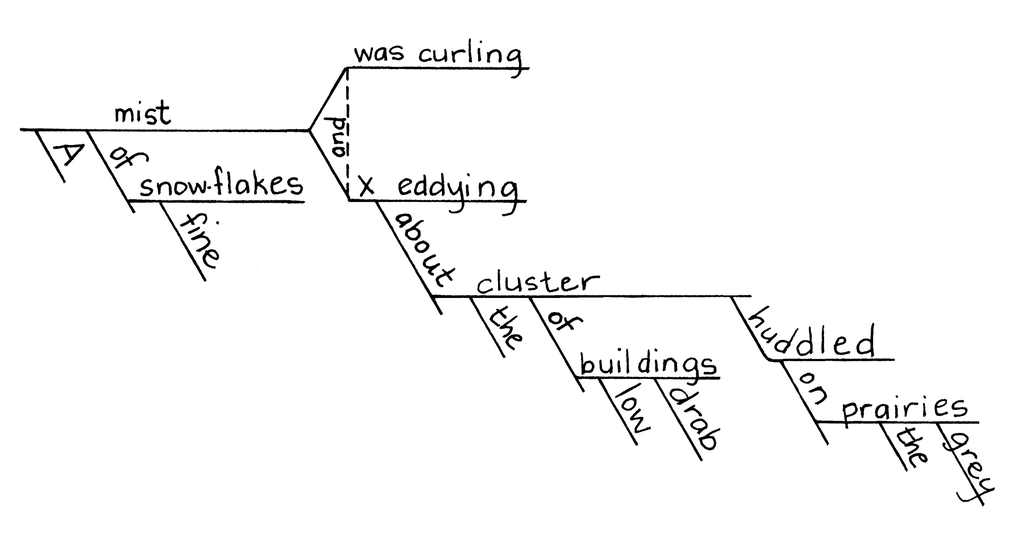

**6. 连接复合谓词的准并列连词：**用水平虚线表示准并列连词，连接它们所连接的词。

**6. Quasi-coordinators joining compound predicates:** Diagram quasi-coordinators on a horizontal dotted line between the words they connect.

我 宁愿饿死 也不 吃开心果。

I will starve rather than eat pistachio.

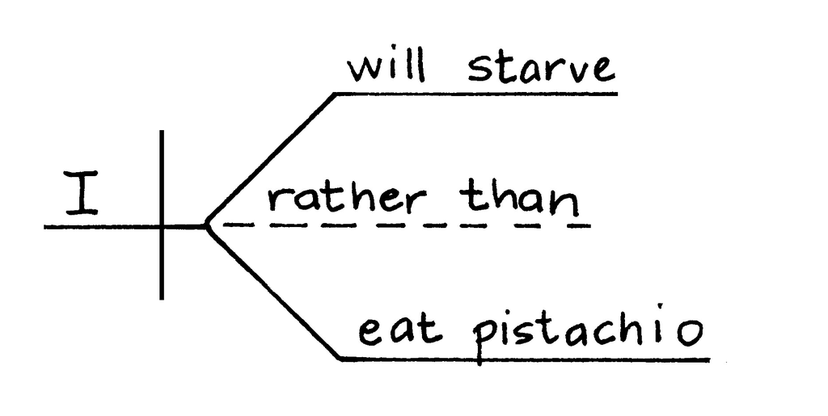

*改编自伊丽莎白·乔治·斯皮尔的*《黑鸟池塘的女巫》*

* adapted from *The Witch of Blackbird Pond* by Elizabeth George Speare

†改编自尾崎叶伊的*《日本童话》*

† adapted from *Japanese Fairy Tales* by Yei Theodora Ozaki

‡改编自查尔斯·狄更斯的*《圣诞颂歌》*

‡ adapted from *A Christmas Carol* by Charles Dickens

<sup>§</sup>改编自凯特·道格拉斯·威金的*《阳光农场的丽贝卡》*

<sup>§</sup> adapted from *Rebecca of Sunnybrook Farm* by Kate Douglas Wiggin

<sup>¶</sup>*改编自尼克·格里夫斯在《河马长毛的时候：以及其他非洲故事》*中讲述的《狒狒智胜豹子的一天》

<sup>¶</sup> adapted from “The Day Baboon Outwitted Leopard,” as told by Nick Greaves in *When Hippo Was Hairy: And Other Tales from Africa*

出自乔治·麦克唐纳的*《光之公主及其他童话故事*<sup>》</sup>

<sup>#</sup> from *The Light Princess and Other Fairy Stories* by George MacDonald

**摘自马克·吐温的《*汤姆·索亚历险记》*

** from *The Adventures of Tom Sawyer* by Mark Twain

††改编自薇拉·凯瑟的《*啊，拓荒者！》*

†† adapted from *O Pioneers!* by Willa Cather

第二部分：如何绘制形容词和副词的结构图

PART II: HOW TO DIAGRAM ADJECTIVES AND ADVERBS

IIA. 形容词

IIA. Adjectives

**1. 描述性形容词：**在它所修饰的词下方，用斜线画出描述性形容词的结构图。

**1. Descriptive adjectives:** Diagram a descriptive adjective on a slanted line underneath the word it is modifying.

一团巨大的、翻滚的 风暴云 正在逼近。*

A colossal, billowing storm-cloud threatened.*

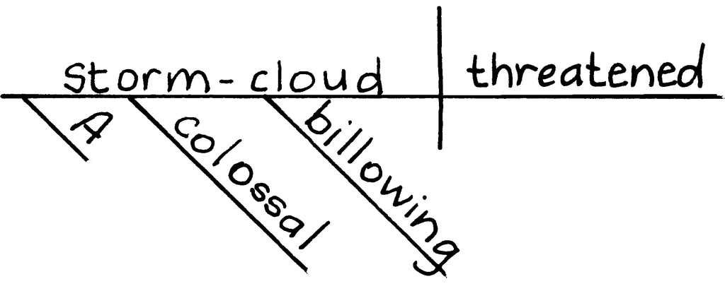

**2. 复合形容词（由多个词组成的单个形容词）：**复合形容词与复合名词一样，放在一行上，并包含任何连字符（如果有的话）。

**2. Compound adjectives (single adjectives made up of more than one word):** A compound adjective, like a compound noun, goes on a single line and includes any hyphen (if present).

一个铁甲 怪物 出现了。†

An iron-plated monster had arisen.†

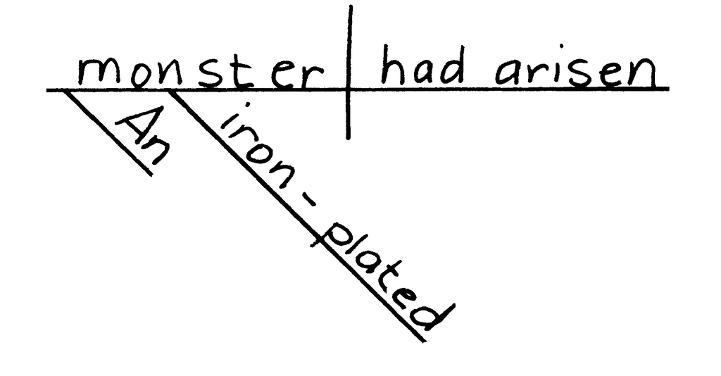

**3. 冠词：**与其他形容词一样，冠词（*a、an、the*）用斜线表示，位于它们所修饰的名词下方。

**3. Articles:** Like other adjectives, articles (*a, an, the*) are diagrammed on slanted lines beneath the nouns they describe.

彩虹 之女和玫瑰 公主 向她们走来<sup>。</sup>

The Rainbow’s Daughter and the Rose Princess approached them.‡

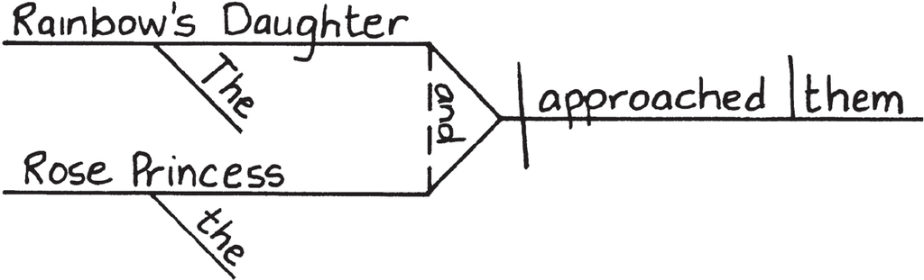

**4. 复合形容词（两个或多个形容词修饰同一个名词）：当两个形容词修饰同一个名词，并且由***and*连接时，它们用斜线表示在它们所修饰的名词下方，而连接词则用虚线表示，将两个形容词连接在一起。

**4. Compound adjectives (two or more adjectives modifying the same noun):** When two adjectives modify the same noun and are linked by *and*, they are diagrammed on slanted lines underneath the noun they modify, and the conjunction is written on a dotted line linking the two adjectives together.

高而宽 的拱门 并不常见。

Tall and wide arches weren’t often built.

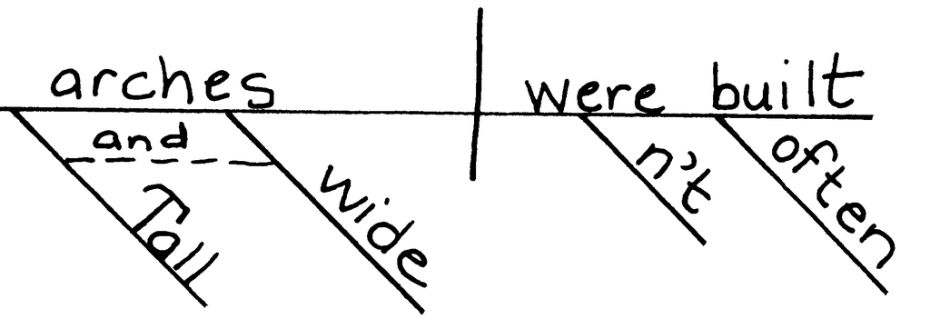

**5. 所有格代词作形容词：**当所有格代词用作所有格形容词时，它用斜线表示为它所修饰的词。

**5. Possessive pronouns as adjectives:** When a possessive pronoun is being used as a possessive adjective, it is diagrammed on a slanted line under the word it modifies.

她的 热情 治愈了<sup>埃德蒙</sup>。

Her cordial healed Edmund.<sup>§</sup>

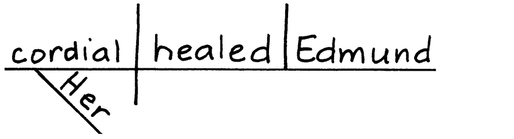

**6. 不定代词作形容词**：当不定代词用作形容词时，它放在它所修饰的词的斜线下方。

**6. Indefinite pronouns acting as adjectives**: When an indefinite pronoun is being used as an adjective, it is placed on a slanted line under the word it modifies.

许多 客人提前 到达。

Many guests arrived early.

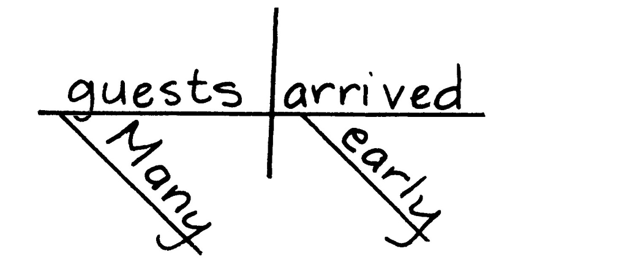

**7. 指示代词作形容词：**当指示代词（*this、that、these、those*）用作形容词时，它放在它所修饰的词的斜线下方。

**7. Demonstrative pronouns as adjectives:** When a demonstrative pronoun (*this, that, these, those*) is used as an adjective, it is placed on a slanted line under the word it modifies.

梅里韦瑟夫人 是那些没有孩子的成年人之一<sup>。</sup>

Mrs. Merriweather was one of those childless adults.<sup>¶</sup>

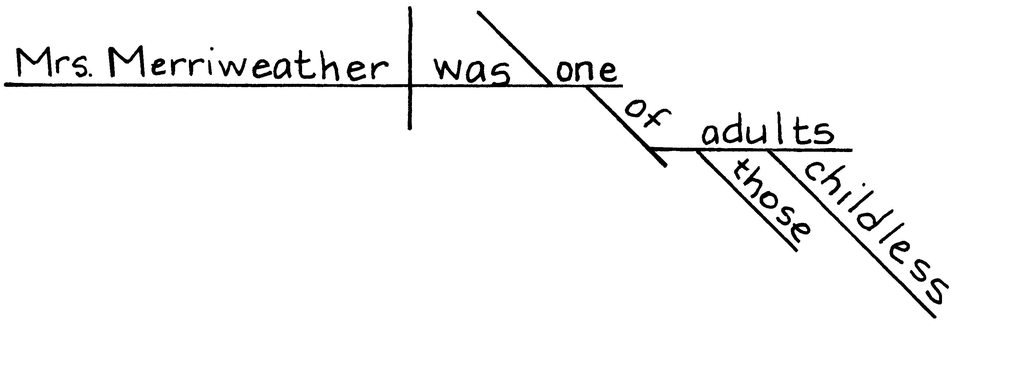

**8. 疑问代词作形容词：**疑问代词*whose、what*和*which*也可以用作形容词。它们的结构式与其他形容词一样，用斜线表示，位于它们所修饰的词下方。

**8. Interrogative pronouns as adjectives:** The interrogative pronouns *whose, what*, and *which* can also be used as adjectives. They are diagrammed like other adjectives, on a slanted line under the word they are modifying.

谁的 毯子 不见了？

Whose blanket is missing?

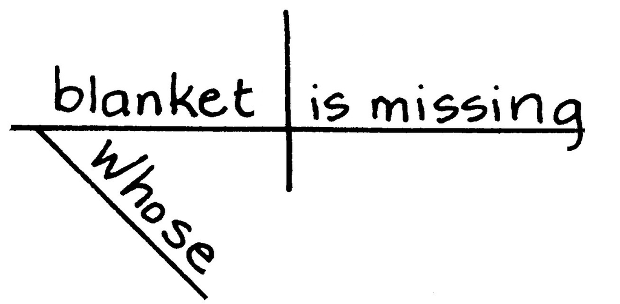

**9. 过去分词作形容词：**当动词的过去分词作描述性形容词时，它被放在它所修饰的名词下方的一条斜线上。然而，这条斜线必须弯曲并变成直线。由于形容词用斜线表示，动词用直线表示，这种类型的线表明过去分词同时具有形容词和动词的性质。

**9. Past participles as adjectives:** When the past participle of a verb acts as a descriptive adjective, it is placed on a slanted line beneath the noun it modifies. However, the slanted line must curve around and become straight. Since adjectives are diagrammed on slanted lines, and verbs are diagrammed on straight lines, this type of line shows that the past participle has both adjective qualities and verb qualities.

爆裂的 气球 正好能放进蜂蜜罐里。

The burst balloon fit inside the honey jar.

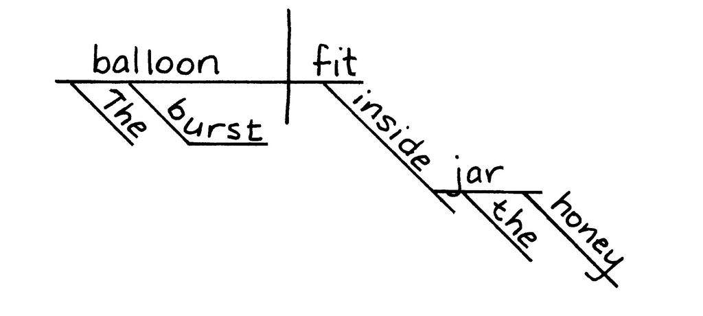

**10. 现在分词作形容词：**当动词的现在分词作描述性形容词时，它被放在它所修饰的名词下方的一条斜线上。然而，这条斜线必须弯曲并变成直线。由于形容词用斜线表示，动词用直线表示，这种类型的线表明现在分词同时具有形容词和动词的性质。

**10. Present participles as adjectives:** When the present participle of a verb acts as a descriptive adjective, it is placed on a slanted line beneath the noun it modifies. However, the slanted line must curve around and become straight. Since adjectives are diagrammed on slanted lines, and verbs are diagrammed on straight lines, this type of line shows that the present participle has both adjective qualities and verb qualities.

打着鼾的 守卫们 躺在门口，睡得正香。

The snoring guards lay at the doorstep, fast asleep.

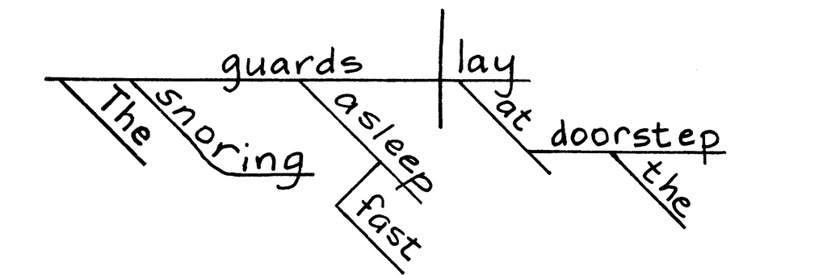

IIB. 副词

IIB. Adverbs

**1. 修饰动词的副词：**副词放在它所修饰的动词下方的斜线上。

**1. Adverbs that modify verbs:** An adverb goes on a slanted line beneath the verb it modifies.

他们 安详地休息了 。

They rested peacefully.

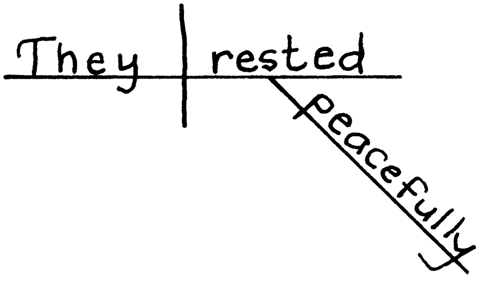

**2. 修饰形容词的副词：**修饰形容词的副词放在它所修饰的形容词下方的斜线上。

**2. Adverbs that modify adjectives:** An adverb that describes an adjective goes on a diagonal line underneath the adjective it modifies.

极度胆小的拉里 跑开了。

Extremely skittish Larry ran away.

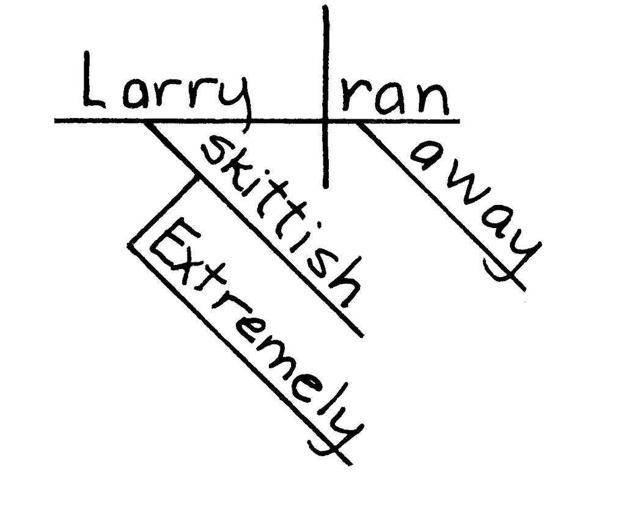

**3. 修饰其他副词的副词：**修饰另一个副词的副词放在被修饰副词的下方的对角线上。

**3. Adverbs that modify other adverbs:** An adverb that describes another adverb goes on a diagonal line underneath the adverb it modifies.

拉里发出了一声 格外响亮的尖叫 。

Larry shrieked especially loudly.

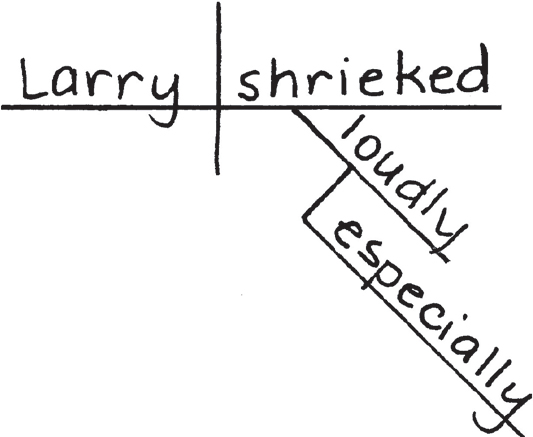

**4. 复合副词（两个或多个副词修饰同一个词）：**当两个副词修饰同一个词，并且由*and*连接时，它们用斜线表示在它们所修饰的词的下方，而连接词则用虚线表示，将两个副词连接在一起。

**4. Compound adverbs (two or more adverbs modifying the same word):** When two adverbs modify the same word and are linked by *and*, they are diagrammed on slanted lines underneath the word they modify, and the conjunction is written on a dotted line linking the two adverbs together.

这种观点 由来已久 ，广为 流传。

The idea was deeply and widely held.

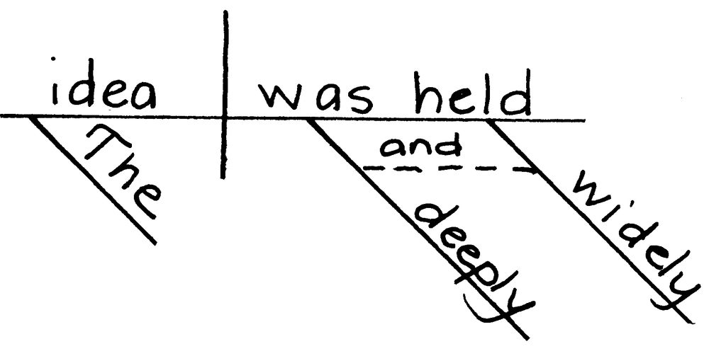

**5. 疑问代词作副词：**当疑问代词回答副词性问题（*哪里、何时、如何、多久一次、达到什么程度*）时，它们被表示为副词，用斜线表示它们所修饰的动词。

**5. Interrogative pronouns as adverbs:** When interrogative pronouns answer the adverb questions (*where, when, how, how often, to what extent*), they are diagrammed as adverbs, on a slanted line under the verb(s) they are modifying.

你在 哪？

Where are you?

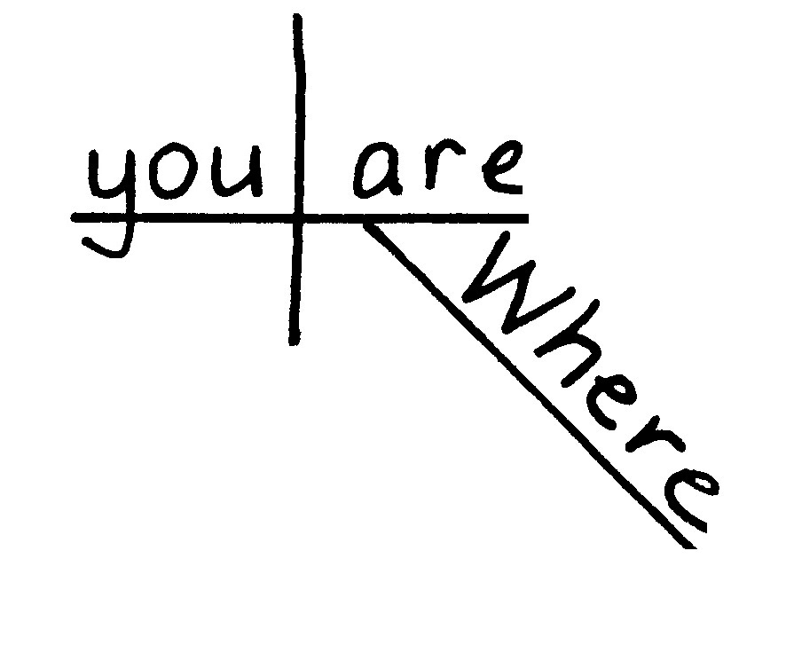

**6. 肯定副词：**诸如*yes、surely、definitely、certainly、absolutely*和*very*之类的副词使肯定句更具肯定性。它们用斜线标示在它们所修饰的词语下方。

**6. Adverbs of affirmation:** Adverbs such as *yes, surely, definitely, certainly, absolutely*, and *very* make positive statements more affirming. They are diagrammed on a slanted line under the word or words they modify.

是的，我 会为你画像，胡安尼科。<sup>#</sup>

Yes, I will paint you, Juanico.<sup>#</sup>

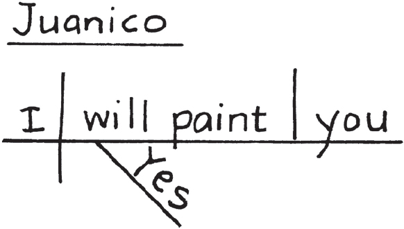

**7. 否定副词：***no、not*和*never*可以用作否定副词，表示某事不成立或不存在。它们用斜线标示在所修饰的词下方。当它们用作缩写词的一部分时，斜线上只标示缩写部分。

**7. Adverbs of negation:** The words *no, not*, and *never* can be used as adverbs of negation, stating what is not true or does not exist. They are diagrammed on a slanted line under the word or words they modify. When they are used as part of a contraction, they are diagrammed with only the contracted portion of the word on the slanted line.

你 将 永远不会再 被<sup>打败</sup>。

You will never be beaten again.**

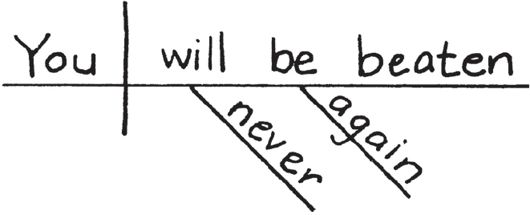

没关系 。

It doesn’t matter.

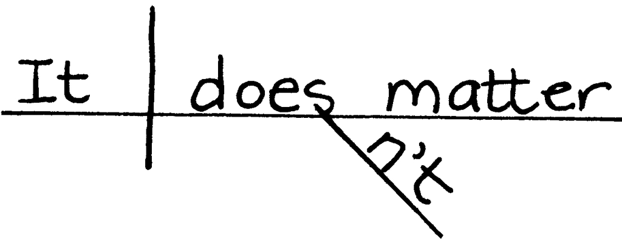

*改编自儒勒·凡尔纳的*《海底两万里》*

* adapted from *Twenty Thousand Leagues Under the Sea* by Jules Verne

†改编自儒勒·凡尔纳的*《海底两万里》*

† adapted from *Twenty Thousand Leagues Under the Sea* by Jules Verne

‡出自L. Frank Baum 的*《绿野仙踪的滴答声》*

‡ from *Tik-Tok of Oz* by L. Frank Baum

§改编自C·S·刘易斯的*《狮子、女巫和衣橱》*

§ adapted from *The Lion, The Witch, and the Wardrobe* by C. S. Lewis

摘自哈珀·李的*《杀死一只知更鸟*》

¶ from *To Kill A Mockingbird* by Harper Lee

#选自*《我，胡安·德·帕雷哈》*作者：伊丽莎白·博顿·德·特雷维诺

# from *I, Juan de Pareja* by Elizabeth Borton de Treviño

**摘自*《我，胡安·德·帕雷哈》*作者：伊丽莎白·博顿·德·特雷维诺

** from *I, Juan de Pareja* by Elizabeth Borton de Treviño

第三部分：如何绘制介词短语图

PART III: HOW TO DIAGRAM PREPOSITIONAL PHRASES

IIIA. 介词短语作修饰语

IIIA. Prepositional phrases acting as modifiers

**1. 作形容词的介词短语：**修饰名词或代词的介词短语的图示应位于其所修饰的词语下方。介词位于对角线上，介词宾语位于水平线上，修饰宾语的任何形容词都位于宾语下方的对角线上。

**1. Prepositional phrases that act as adjectives:** Prepositional phrases that modify nouns or pronouns are diagrammed underneath the word or words they modify. The preposition is placed on a diagonal line, the object of the preposition is placed on a horizontal line, and any adjectives modifying the object go on diagonal lines underneath the object.

卡莱布 爬上了一棵枝繁叶茂的大树。

Caleb climbed a tree with thick branches.

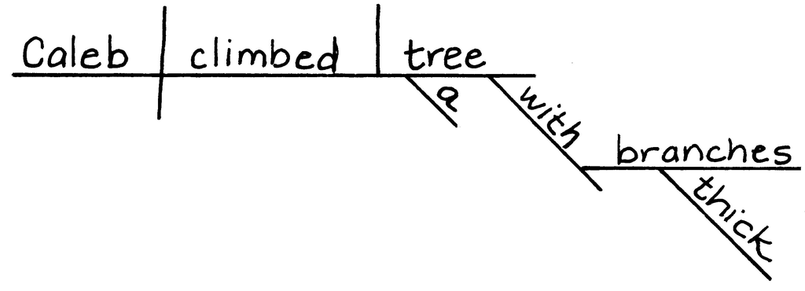

**2. 作表语形容词的介词短语：**介词短语可以作形容词来描述主语。它在图示中位于斜线之后，紧随系动词之后，并置于基座上。介词位于对角线上，介词宾语位于水平线上，任何修饰语都位于宾语下方的对角线上。

**2. Prepositional phrases that act as predicate adjectives:** A prepositional phrase can act as an adjective describing the subject. It is diagrammed after the slanted line, following the linking verb, and it is placed on a pedestal. The preposition is put on a diagonal line, the object of the preposition is on a horizontal line, and any modifiers are placed on a diagonal line underneath the object.

这个男人 恋爱了 。

The man is in love.

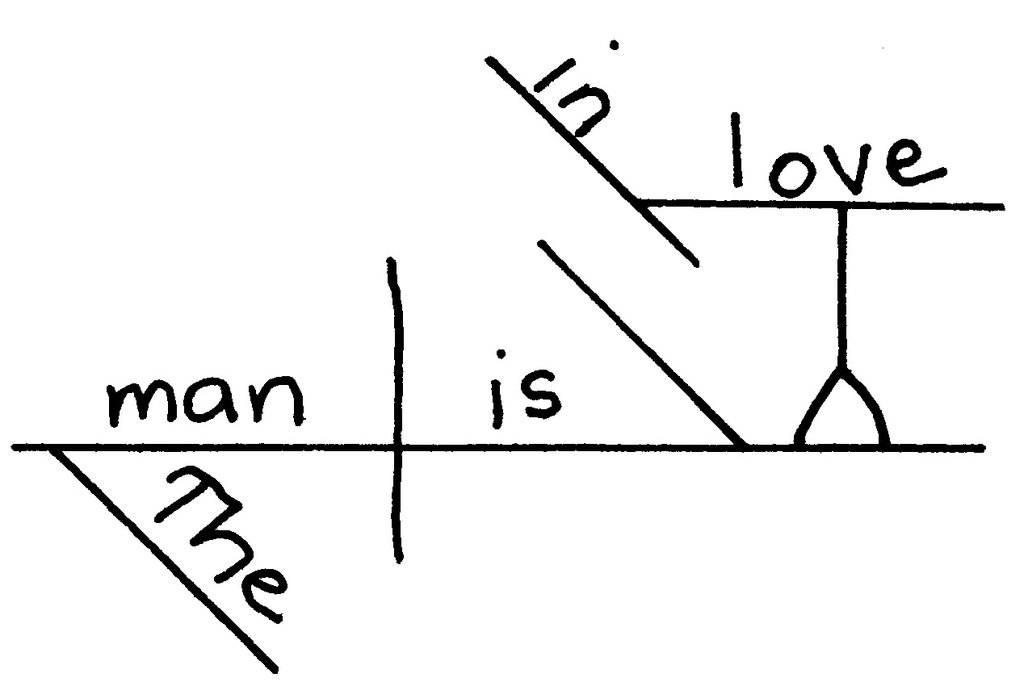

**3. 介词短语修饰其他介词短语：**当一个介词短语作形容词或副词时，它有时可以被另一个介词短语修饰。第二个短语的结构图如下所示。

**3. Prepositional phrases modifying other prepositional phrases:** When a prepositional phrase is acting as an adjective or adverb, it can sometimes be modified by another prepositional phrase. The second phrase is diagrammed below the first.

地平线附近的较小物体可能会影响我们对月球大小的看法。

Smaller objects near the horizon might influence our ideas about the size of the moon.

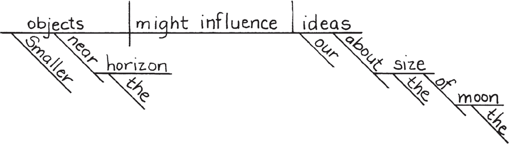

**4. 作副词的介词短语：当一个介词短语回答***“如何”、“何时”、“何地”、“多久一次”、“程度如何”等*问题时，它就是一个副词短语。它的图示位于它所修饰的动词、形容词或副词下方。介词位于对角线上，介词宾语位于水平线上，修饰宾语的形容词位于宾语下方的对角线上。

**4. Prepositional phrases that act as adverbs:** When a prepositional phrase answers one of the questions *how, when, where, how often, to what extent*, it is an adverb phrase. It is diagrammed under the verb, adjective, or adverb that it modifies. The preposition is placed on a diagonal line, the object of the preposition is placed on a horizontal line, and any adjectives modifying the object go on diagonal lines underneath the object.

汉克·阿伦 充满自信地挥动球棒。

Hank Aaron swung the bat through the air with great confidence.

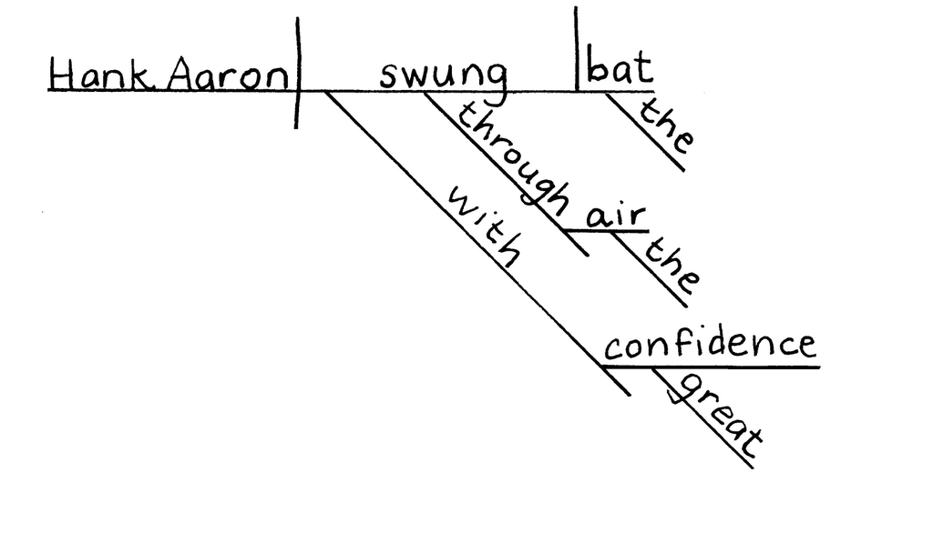

IIIB. 作名词的介词短语

IIIB. Prepositional phrases acting as nouns

**1. 作主语的介词短语：**当介词短语作主语时，它在主语线上用基座表示。

**1. Prepositional phrases that act as subjects:** When the prepositional phrase acts as the subject, it is diagrammed on a pedestal on the subject line.

桥下 不是安全的地方。

Under the bridge is not a safe place.

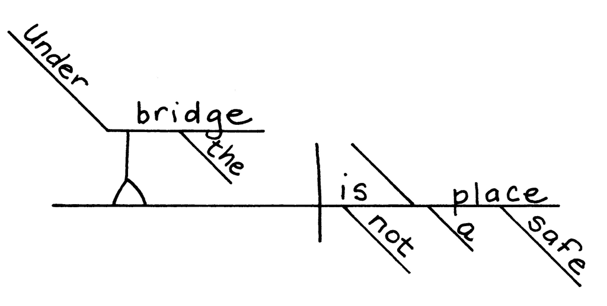

**2. 作直接宾语的介词短语：**当介词短语承受动词的动作时，它就作直接宾语。图示中，它位于水平线上的基座上，并置于动作动词之后。动词和宾语之间画一条竖线。但是，这条竖线止于水平线，并不穿过水平线。

**2. Prepositional phrases that act as direct objects:** When the prepositional phrase receives the action of the verb, it is acting as a direct object. It is diagrammed on a pedestal on a horizontal line, and it is placed after the action verb. A vertical line is drawn between the verb and the object. However, the vertical line stops at the horizontal line and does not go through.

兰恩以前 从未见过毛克利，当然，他听说过<sup>毛克利</sup>这个人。

Rann had never seen Mowgli before, though of course he had heard of him.*

[figure not shown]

**3. 作表语的介词短语：**当介词短语重新命名主语时，它就作表语。它在示意图中被放置在水平线上的基座上，位于系动词和指向主语的斜线之后。

**3. Prepositional phrases that act as predicate nominatives:** When the prepositional phrase renames the subject, it is acting as a predicate nominative. It is diagrammed on a pedestal on a horizontal line, and it is placed after the linking verb and a slanted line pointing back to the subject.

藏宝的最佳地点是 床底下。